# MAS2908 - Practical 03 (Solutions)

Putting It All Together

Clement Lee

Semester 2, 2025/2026

# 1 Introduction

This practical brings together what we’ve covered so far:

- **Practical 1**: Data frames, including how to access columns and rows
- **Practical 2**: R Markdown, including chunk options for controlling output
- **Chapter 3**: `ggplot2`

The goal is to create a complete, reproducible analysis document that combines data exploration with professional visualisations.

## 1.1 Key concepts recap

In Practical 1, you learned about data frames — the fundamental structure for storing tabular data in R. You accessed columns using `$` notation (e.g., `mtcars$mpg`) and explored built-in datasets.

In Practical 2, you learned how to create R Markdown documents that weave together code, output, and narrative text. You used chunk options to control what appears in your final document:

| Goal | Chunk option |
| --- | --- |
| Hide code, show output | `#\| echo: false` |
| Hide everything | `#\| include: false` |
| Figure caption | `#\| fig.cap: "..."` |
| Figure size | `#\| fig.width`, `#\| fig.height` |

In lectures, you learned about `ggplot2` and the grammar of graphics:

```r
ggplot(data, aes(x = var1, y = var2)) +
  geom_*() +
  labs(x = "X Label", y = "Y Label", title = "Title")
```

Now we combine all three: create `ggplot2` visualisations inside an R Markdown document, using chunk options to produce professional output.

# 2 Creating ggplots in R Markdown

When you create a `ggplot` in an R Markdown code chunk, the plot is automatically included in your output document. Here’s an example:

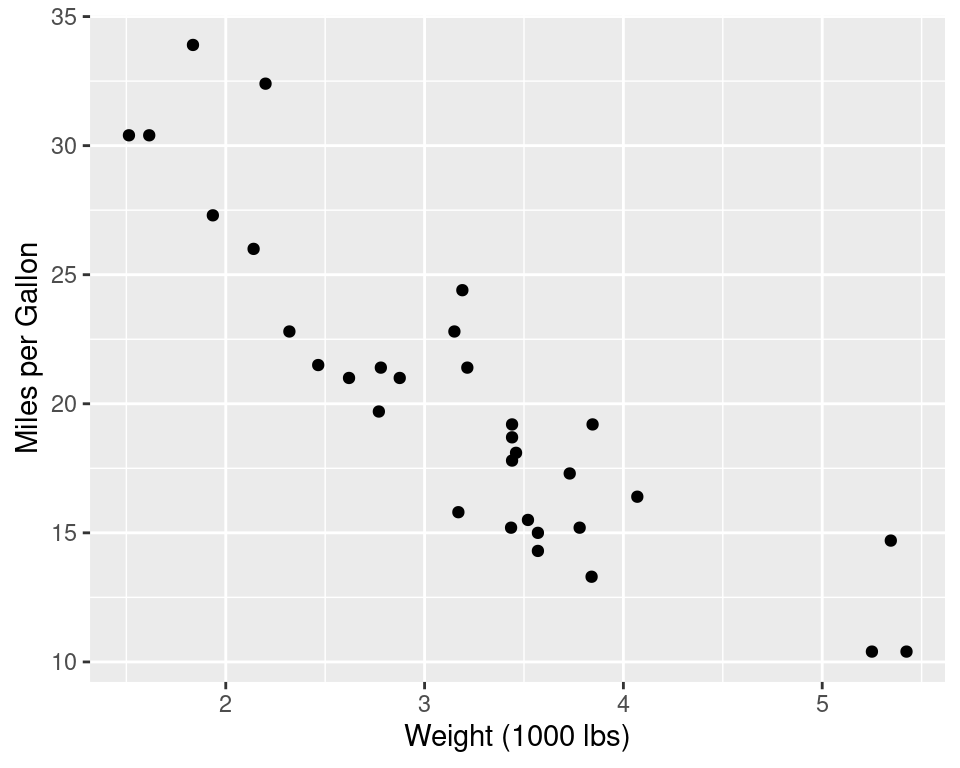

Figure 2.1: Scatterplot of weight vs fuel efficiency.

```r
ggplot(mtcars, aes(x = wt, y = mpg)) +
  geom_point() +
  labs(x = "Weight (1000 lbs)", y = "Miles per Gallon")
```

A typical analysis workflow in R Markdown involves:

1. **Load packages** (in a setup chunk with `#| include: false`)
2. **Import data** (or use built-in datasets)
3. **Explore and clean data** (packages such as `dplyr` are useful here)
4. **Create visualisations** (with appropriate chunk options)
5. **Interpret results** (in the narrative text)

Tips for professional output:

- **Always add axis labels**: Use `labs()` to make plots self-explanatory.
- **Use figure captions**: Add `#| fig.cap: "..."` to your chunk options.
- **Control figure size**: Use `#| fig.width` and `#| fig.height` for the actual dimensions, and `#| out.width` for how much space it takes.
- **Hide code for reports**: Use `#| echo: false` so readers see only the visualisation, not the code. **Note**: in these practicals, especially the solutions, the code is sometimes included for illustration. In the assignments and exam, whether you need to hide the code will be specified.

# 3 Exercises

In this exercise, you will create an R Markdown document that contains 7 different types of visualisations using the `mpg` dataset (fuel economy data for 234 vehicles). Your final document should include:

- The 7 plots (one for each question below)
- A brief written interpretation after each plot
- Professional formatting using chunk options

**Getting started:**

1. Create a new R Markdown document: **File > New File > R Markdown…**
2. Choose “Document” and “PDF” output
3. Save it as `practical03_plots.Rmd`
4. In your setup chunk, load `ggplot2`:

````markdown
```{r setup}
#| include: false
library(ggplot2)
```
````

**For each question:**

- Create the plot in its own code chunk
- Add a figure caption using `#| fig.cap: "..."`
- Hide the code using `#| echo: false`
- Write 1-2 sentences interpreting what you observe

When you have completed all 7 plots, knit your document to PDF.

1. **Histogram**: Create a histogram of `cty` using `geom_histogram()`. Experiment with different `binwidth` values (try 1, 2, and 5). Add appropriate axis labels using `labs()`. In your interpretation, describe whether the distribution is symmetric or skewed.

   **Answer**: The distribution is right-skewed with most vehicles getting 15-20 city MPG.

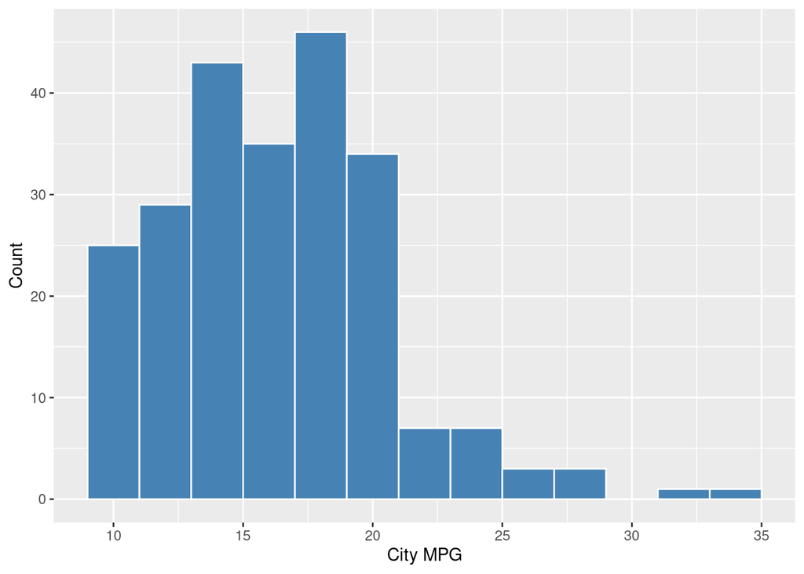

   Figure 3.1: Distribution of city fuel efficiency.

   ```r
   ggplot(mpg, aes(x = cty)) +
     geom_histogram(binwidth = 2, fill = "steelblue", colour = "white") +
     labs(x = "City MPG", y = "Count")
   ```

2. **Density plot**: Create a density plot of `cty` using `geom_density()`. Add a rug plot underneath using `geom_rug()`. In your interpretation, compare this to the histogram — what does the density plot show that the histogram doesn’t (and vice versa)?

   **Answer**: Density plot shows a smoother view of the distribution shape. Histogram shows actual counts and is affected by bin width choice

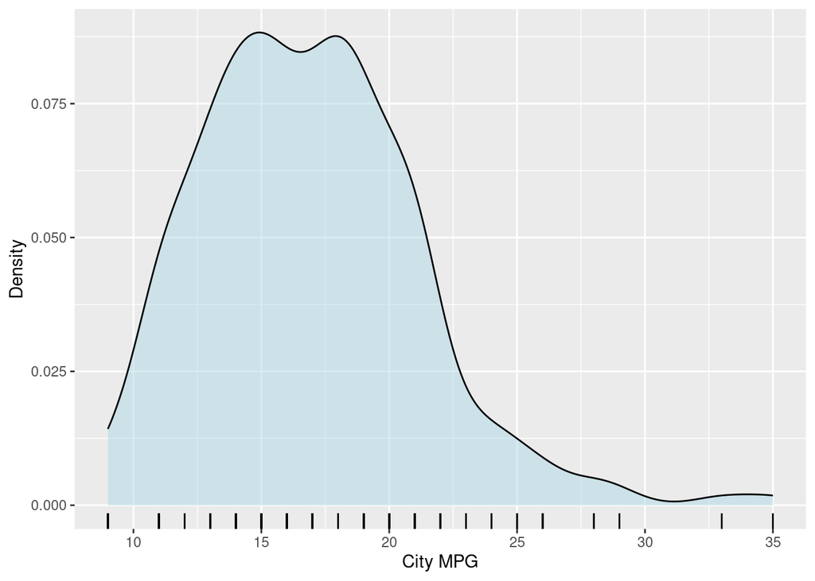

   Figure 3.2: Density of city fuel efficiency.

   ```r
   ggplot(mpg, aes(x = cty)) +
     geom_density(fill = "lightblue", alpha = 0.5) +
     geom_rug() +
     labs(x = "City MPG", y = "Density")
   ```

3. **Bar chart**: Create a bar chart of `class` (vehicle type) using `geom_bar()`. Add appropriate axis labels. In your interpretation, state which vehicle class is most common in the dataset.

   **Answer**: SUV is the most common vehicle class

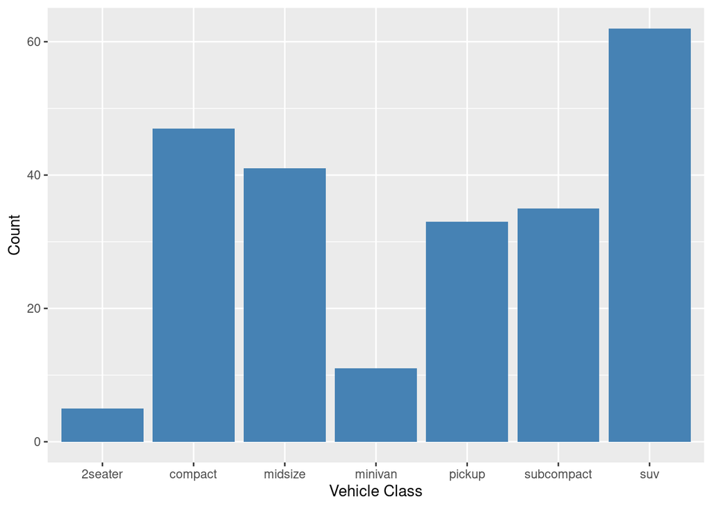

   Figure 3.3: Bar chart of vehicle type.

   ```r
   ggplot(mpg, aes(x = class)) +
     geom_bar(fill = "steelblue") +
     labs(x = "Vehicle Class", y = "Count")
   ```

4. **Scatterplot**: Explore the relationship between `cty` and `hwy`. Create a scatterplot of `cty` ($y$-axis) vs `hwy` ($x$-axis) using `geom_point()`. Add a trend line using `geom_smooth(method = "lm")`. In your interpretation, describe the relationship you observe.

   **Answer**: Strong positive linear relationship: higher highway MPG = higher city MPG

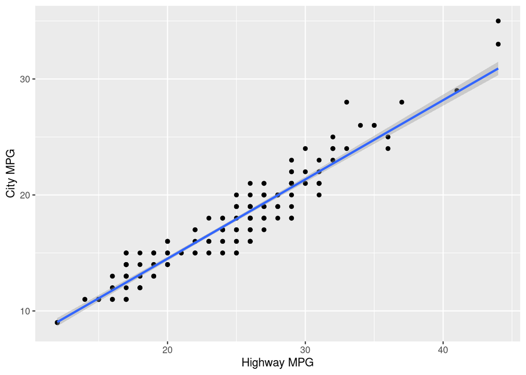

   Figure 3.4: City fuel efficiency against highway fuel efficiency.

   ```r
   ggplot(mpg, aes(x = hwy, y = cty)) +
     geom_point() +
     geom_smooth(method = "lm") +
     labs(x = "Highway MPG", y = "City MPG")
   ```

5. **Line plot**: Create a line plot using the `economics` dataset. Plot `psavert` (personal savings rate) over time using `geom_line()`. Add appropriate axis labels. In your interpretation, describe the trend you observe.

   **Answer**: General declining trend from 1970s to 2005, then increase after 2008 crisis

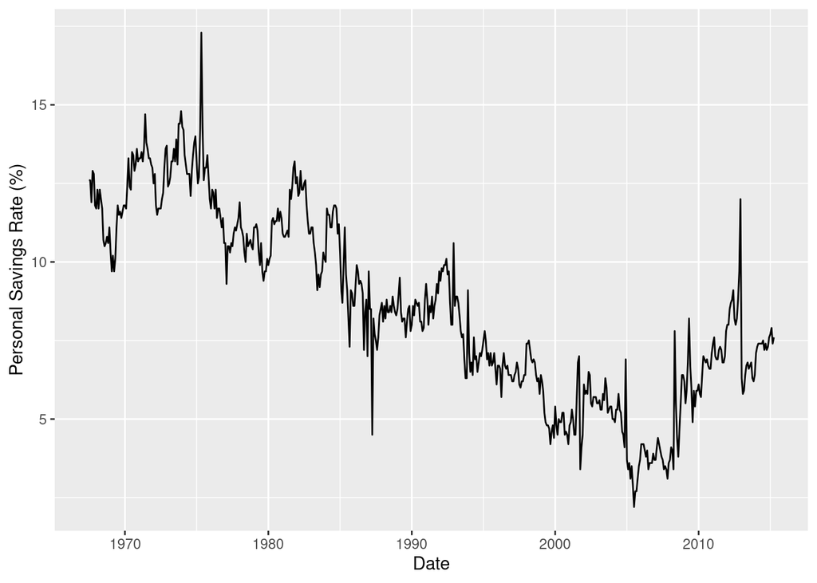

   Figure 3.5: Personal saving rates over time.

   ```r
   ggplot(economics, aes(x = date, y = psavert)) +
     geom_line() +
     labs(x = "Date", y = "Personal Savings Rate (%)")
   ```

6. **Stripchart**: Create a stripchart of `cty` by `class` using `geom_jitter()` with `width = 0.2`. Add appropriate axis labels.

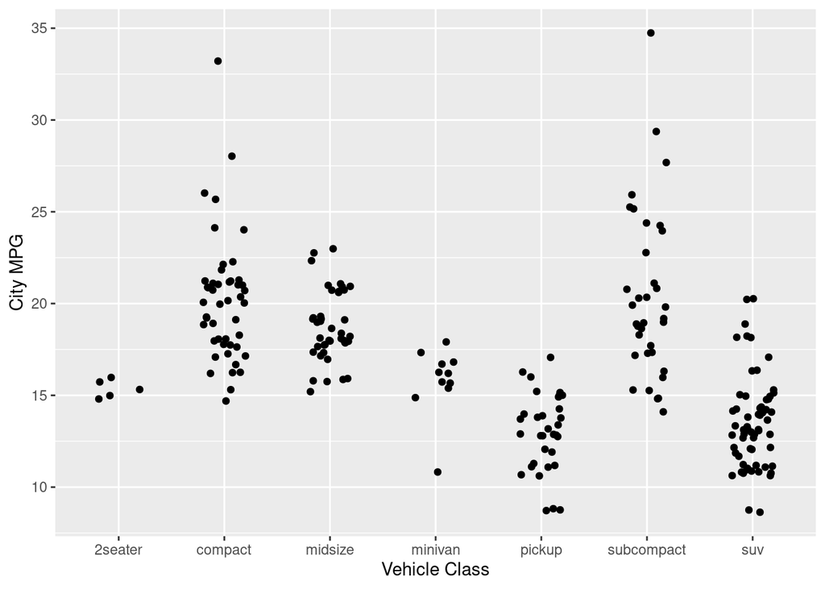

   ```r
   ggplot(mpg, aes(x = class, y = cty)) +
     geom_jitter(width = 0.2) +
     labs(x = "Vehicle Class", y = "City MPG")
   ```

7. **Boxplot**: Compare the distribution of `cty` across vehicle classes using `geom_boxplot()` with `aes(x = class, y = cty)`. Add appropriate axis labels. Combine the boxplot with a jitter plot (use `outlier.shape = NA` in the boxplot to avoid duplicate points). In your interpretation, state which vehicle class has the best city fuel efficiency.

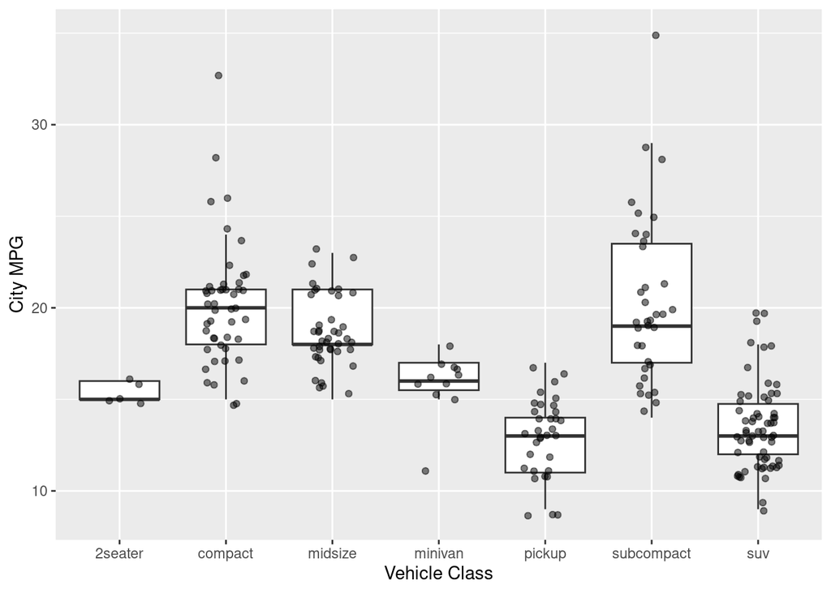

   Figure 3.7: Boxplot of city fuel efficiency by vehicle class, overlayed by stripchart / jitter plot.

   ```r
   ggplot(mpg, aes(x = class, y = cty)) +
     geom_boxplot(outlier.shape = NA) +
     geom_jitter(width = 0.2, alpha = 0.5) +
     labs(x = "Vehicle Class", y = "City MPG")
   ```

8. **Create a complete analysis document**

   Using another dataset such as `mtcars` or `airquality`, create a complete R Markdown document that includes:
   1. An appropriate title and brief introduction
   2. At least three different types of plots (e.g., histogram, boxplot, scatterplot)
   3. Proper figure captions for each plot
   4. Consistent figure sizing throughout
   5. Hidden code (using `#| echo: false`)
   6. Brief interpretation after each plot

   **Answer**: This is left as an exercise.

# 4 Summary

This practical demonstrated how to:

- Combine data exploration with visualisation (`ggplot2`)
- Create reproducible analysis documents with R Markdown
- Use chunk options to control the appearance of code and figures
- Structure a workflow from data to insights

In future practicals, we will build on these skills to create more sophisticated visualisations using colours, scales, faceting, and themes.